# Summary of Results for Jackson and Layan

SID: 490300286

30 October, 2021

# summary of results

## background

Our main investigation is to see how do the different food groups affect measures of obesity.

We have used the 5 major food groups as defined by [australian department of health](https://www1.health.gov.au/internet/publications/publishing.nsf/Content/gug-family-toc~gug-family-foods~gug-family-foods-basic)

These are Meat, Veggies, Fruit, Grains, Dairy.

The measures of obesity we are considering are BMI (BMISC), waist circumference (PHDCMWBC) and waist to height ratio (w2hratio).

To do this we will build linear regression models and compare the coefficients

## Key results

**Checking the significance of each variable on obesity measures**

The table below shows the effect of each food group on the obesity measures.

```r
load_cache("full_models", "full_model_table")
```

|  | BMISC |  |  | PHDCMWBC |  |  | w 2 hratio |  |  |
| --- | --- | --- | --- | --- | --- | --- | --- | --- | --- |
| Predictors | Estimates | std. Error | p | Estimates | std. Error | p | Estimates | std. Error | p |
| (Intercept) | 25.98 | 0.24 | **<0.001** | 89.07 | 0.59 | **<0.001** | 0.49 | 0.00 | **<0.001** |
| avg veges | -0.12 | 0.03 | **<0.001** | -0.29 | 0.08 | **<0.001** | -0.00 | 0.00 | **<0.001** |
| avg fruit | -0.20 | 0.05 | **<0.001** | -0.57 | 0.11 | **<0.001** | -0.00 | 0.00 | **<0.001** |
| avg dairy | 0.10 | 0.07 | 0.141 | 0.18 | 0.16 | 0.255 | -0.00 | 0.00 | 0.275 |
| avg meat | 0.22 | 0.05 | **<0.001** | 0.37 | 0.12 | **0.002** | 0.00 | 0.00 | **0.007** |
| avg grains | -0.17 | 0.03 | **<0.001** | -0.38 | 0.07 | **<0.001** | -0.00 | 0.00 | **<0.001** |
| AGEC | 0.05 | 0.00 | **<0.001** | 0.23 | 0.01 | **<0.001** | 0.00 | 0.00 | **<0.001** |
| SEX [2] | -0.66 | 0.13 | **<0.001** | -10.08 | 0.31 | **<0.001** | -0.02 | 0.00 | **<0.001** |
| Observations | 7811 |  |  | 7811 |  |  | 7811 |  |  |
| R<sup>2</sup> / R<sup>2</sup> adjusted | 0.041 / 0.040 |  |  | 0.190 / 0.190 |  |  | 0.155 / 0.154 |  |  |

In all obesity measures, dairy is the only insignificant one.

Basically if the sign of the coefficient is negative, then as it increases, the obesity measure decreases. The number tells you by how much.

EXAMPLE: Fruit has a coefficient of -0.20 for BMISC. So for every serving of fruit you eat, your BMI decreases by 0.20 units.

NOTE: All of these models are adjusted for age and sex cause they will obviosuly affect the obesity measures. The dataset we used only has adults (18 years or older) to simplify results

Next, the table below shows the standardised beta coeffcients. Basically, this allows you to compare the effect of each across models.

```r
load_cache("st_betas", "st_beta_table")
```

|  | BMISC |  |  | w 2 hratio |  |  | PHDCMWBC |  |  |
| --- | --- | --- | --- | --- | --- | --- | --- | --- | --- |
| Predictors | Estimates | CI | p | Estimates | CI | p | Estimates | CI | p |
| (Intercept) | 0.06 | 0.03 – 0.09 | **<0.001** | 0.09 | 0.06 – 0.12 | **<0.001** | 0.36 | 0.33 – 0.39 | **<0.001** |
| avg veges | -0.05 | -0.07 – -0.02 | **<0.001** | -0.05 | -0.07 – -0.03 | **<0.001** | -0.04 | -0.06 – -0.02 | **<0.001** |
| avg fruit | -0.05 | -0.07 – -0.03 | **<0.001** | -0.07 | -0.09 – -0.05 | **<0.001** | -0.05 | -0.07 – -0.03 | **<0.001** |
| avg dairy | 0.02 | -0.01 – 0.04 | 0.141 | -0.01 | -0.03 – 0.01 | 0.275 | 0.01 | -0.01 – 0.03 | 0.255 |
| avg meat | 0.05 | 0.03 – 0.08 | **<0.001** | 0.03 | 0.01 – 0.05 | **0.007** | 0.03 | 0.01 – 0.06 | **0.002** |
| avg grains | -0.08 | -0.10 – -0.05 | **<0.001** | -0.05 | -0.08 – -0.03 | **<0.001** | -0.06 | -0.09 – -0.04 | **<0.001** |
| AGEC | 0.17 | 0.15 – 0.19 | **<0.001** | 0.38 | 0.36 – 0.40 | **<0.001** | 0.28 | 0.26 – 0.30 | **<0.001** |
| SEX [2] | -0.12 | -0.16 – -0.07 | **<0.001** | -0.18 | -0.22 – -0.14 | **<0.001** | -0.69 | -0.73 – -0.64 | **<0.001** |
| Observations | 7811 |  |  | 7811 |  |  | 7811 |  |  |
| R<sup>2</sup> / R<sup>2</sup> adjusted | 0.041 / 0.040 |  |  | 0.155 / 0.154 |  |  | 0.190 / 0.190 |  |  |

The interpration is a little bit more difficult, but basically it would be

“for every 1SD increase in the variable, the obesity measure increases by $x$ SDs” where $x$ is the coefficient.

E.g. Meat has a standardised beta of 0.05 for BMI, 0.03 for w2hratio, and 0.03 for waist circumference. So Meat servings has a (everso slightly) bigger effect on BMI than the other two.

**seeing if there are any trends in diet composition of obese people**

we use PCA to plot the data. Basically, this is used to visualise all the dietary components (meat, fruit, veg, grains, dairy) in a 2d graph.

We then use clustering to see if there are any commonalities in dietary composition.

Finally we see how many obese people are in each cluster. At this stage, obesity is just BMI > 30. If you find literature for obesity cut off for the other two please let me know and we can chuck that in too.

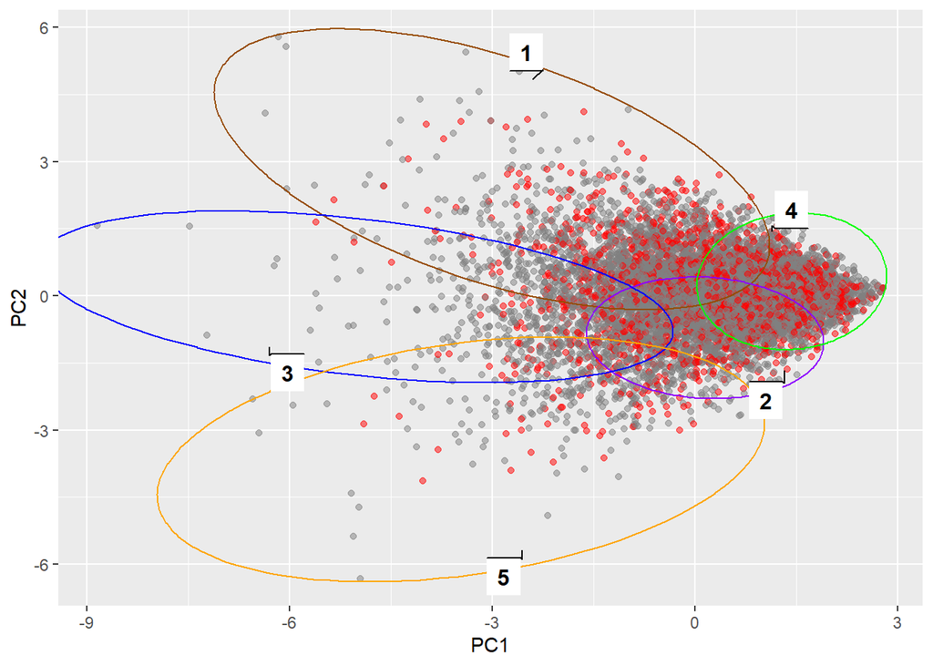

```r
knitr::load_cache("pca", "cluster_ggplot")
```

This plot above is basically just added for data viz cause it looks pretty. Grey dots mean not obese, and red dots means obese. The ellipses circle each cluster. THere are 5 clusters.

```r
knitr::load_cache("pca", "prop_obese")
```

| cl_hierarchical | prop_obese |
| --- | --- |
| 1 | 0.2790943 |
| 2 | 0.2557823 |
| 3 | 0.2075688 |
| 4 | 0.3008280 |
| 5 | 0.2491909 |

This table above shows the proportion of obese in each cluster. Cluster 4 has most obese.

```r
knitr::load_cache("clusters_characteristics", "clusters_characteristics")
```

```
## # A tibble: 5 x 10
##   cl_hierarchical avg_veges avg_dairy avg_fruit avg_meat avg_grains avg_age
##   <fct>               <dbl>     <dbl>     <dbl>    <dbl>      <dbl>   <dbl>
## 1 1                    0.94     -0.3       0.15     1.02       0.06    0.08
## 2 2                   -0.27      0.55      0.05    -0.33       0.26   -0.01
## 3 3                    0.55      0.88      0.93     0.48       1.1    -0.02
## 4 4                   -0.56     -0.55     -0.42    -0.55      -0.57   -0.02
## 5 5                   -0.11      2.55      0.69    -0.22       1.36   -0.21
## # ... with 3 more variables: avg_bmi <dbl>, avg_waist <dbl>, avg_w2hratio <dbl>
```

This table shows the characteristics of each cluster (based upon how many SD each cluster mean is from the overall mean).

For example, cluster 1 has avg_vegs = 0.94, so has 0.94 SD more than the overall average. So simple interpretation is cluster 1 eats above average veges.

# summary of plan

we investigate the effect of diet composition on different measures of obesity.

Obesity can be measured in multiple ways

- BMI
- Waist circumference (https://www.nature.com/articles/s41574-019-0310-7)
- Waist to height ratio (https://bmcmedicine.biomedcentral.com/articles/10.1186/s12916-014-0207-1)

But each of these may categorise obesity differently.

In terms of diet composition, we look at

- daily servings of meat
- daily servings of veg
- daily servings of dairy
- daily servings of fruit
- daily servings of grains

we then want to see what is the effect of each food type on a measurement for obesity (whether it is significant or not), and compare how this varies across each obesity measurement.

> e.g. Maybe meat servings is a significant contributor to BMI but not to waist circumference.

Then, we can compare to see the effect of each food type across different obesity measures. Examples

> e.g. Does fruit servings have a bigger effect on BMI, waist to height ratio, or waist circumference which of the food types has the biggest contribution to BMI reduction/gain.

We can do this by calculating and comparing the standardized betas.

(we can adjust for obvious contributors to each measurement such as age and sex).

```r
# selecting macros
foods = tech_nutr %>% dplyr::select(ABSPID,
                             VEGLEG1N,
                             VEGLEG2N,
                              FRUIT1N,
                              FRUIT2N,
                              DAIRY1N,
                              DAIRY2N,
                              MEAT1N,
                              MEAT2N,
                              GRAINS1N,
                              GRAINS2N)

# gettin average of macros
avg_veges <- rowMeans(foods[ , c(2,3)], na.rm=TRUE)
avg_fruit <- rowMeans(foods[ , c(4,5)], na.rm=TRUE)
avg_dairy <- rowMeans(foods[ , c(6,7)], na.rm=TRUE)
avg_meat <- rowMeans(foods[ , c(8,9)], na.rm=TRUE)
avg_grains <- rowMeans(foods[ , c(10,11)], na.rm=TRUE)


dat <- cbind(tech_nutr$ABSPID,
             avg_veges,
             avg_fruit,
             avg_dairy,
             avg_meat,
             avg_grains)

dat <- as_tibble(dat)
colnames(dat)[1] <- "ABSPID"

dat$avg_veges <- as.numeric(dat$avg_veges)
dat$avg_fruit <- as.numeric(dat$avg_fruit)
dat$avg_dairy <- as.numeric(dat$avg_dairy)
dat$avg_meat <- as.numeric(dat$avg_meat)
dat$avg_grains <- as.numeric(dat$avg_grains)



tech_biom1 = tech_biom %>% dplyr::select(c(1:53))

final = merge(dat, tech_biom1, by = "ABSPID")
final = final %>% dplyr::select(avg_veges,
                         avg_fruit,
                         avg_dairy,
                         avg_meat,
                         avg_grains,
                         BMISC,
                         AGEC,
                         SEX,
                         PHDKGWBC,
                         PHDCMHBC,
                         PHDCMWBC,
                         SF2SA1QN)


final$w2hratio = (final$PHDCMWBC)/(final$PHDCMHBC)

# to make results more robust, focus on adults only

final <- final %>% filter(AGEC > 17)

final = final %>% na.omit()
```

The code in this code chunk just makes a final data frame with the avg servings of each food group for each participant

## IDA on varibales in df

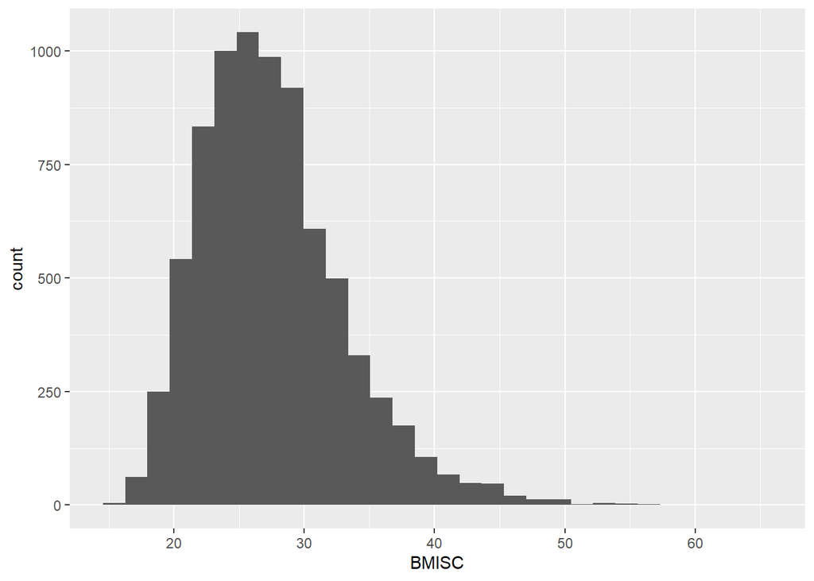

```r
numeric_hist <- function(data, x) {
  ggplot(data, aes_string(x = `x`)) +
  geom_histogram()
}


numeric_hist(final, x = "BMISC")
```

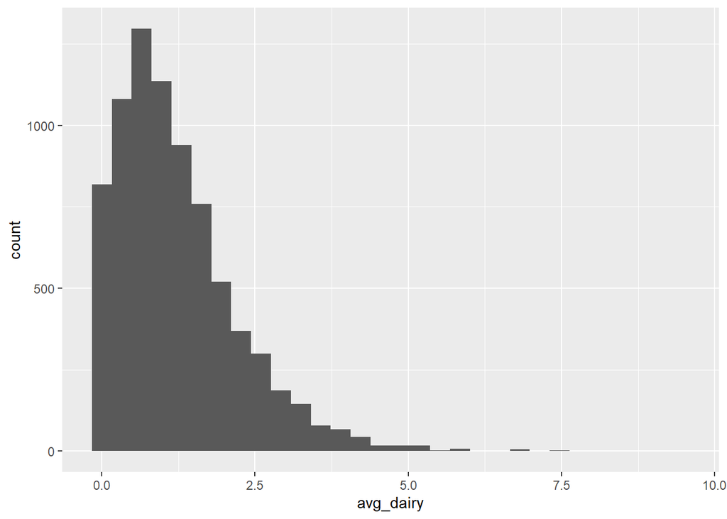

```r
numeric_hist(final, x = "avg_dairy")
```

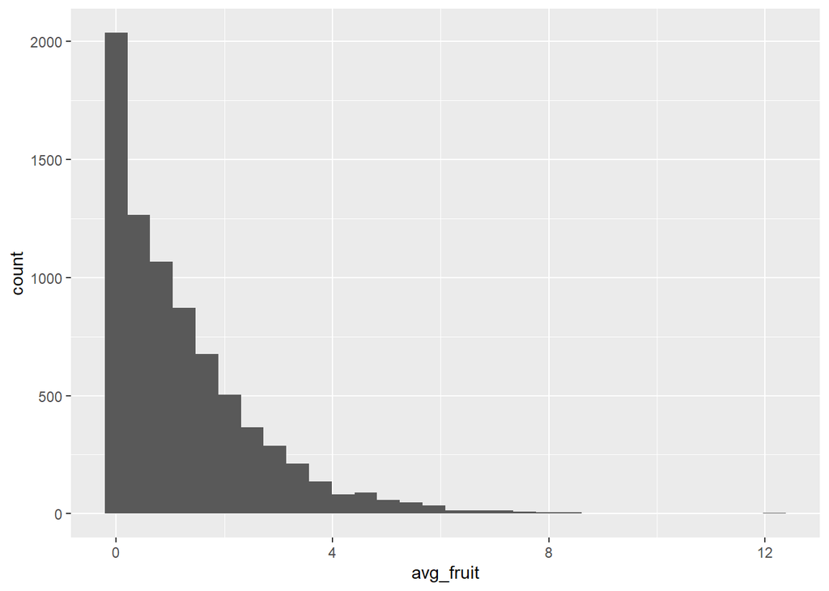

```r
numeric_hist(final, x = "avg_fruit")
```

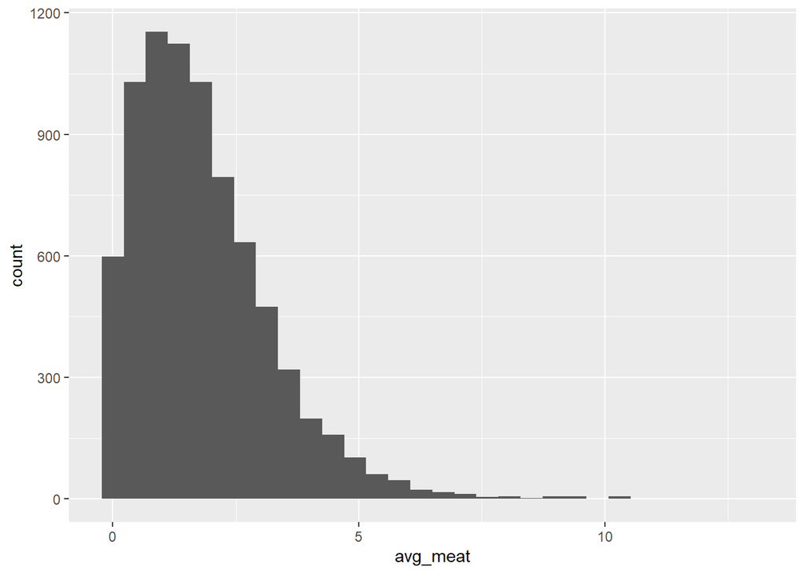

```r
numeric_hist(final, x = "avg_meat")
```

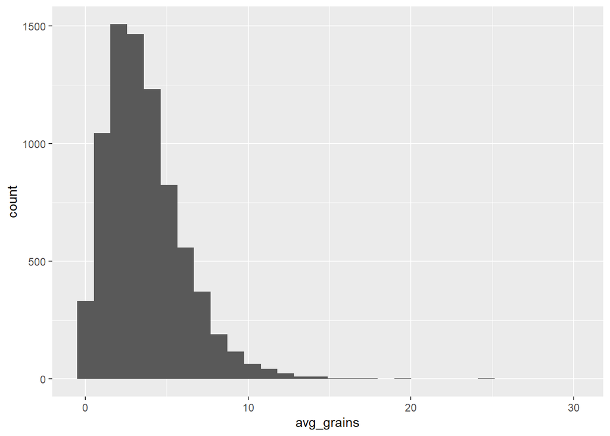

```r
numeric_hist(final, x = "avg_grains")
```

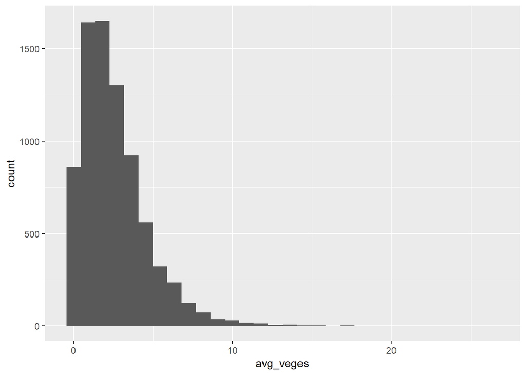

```r
numeric_hist(final, x = "avg_veges")
```

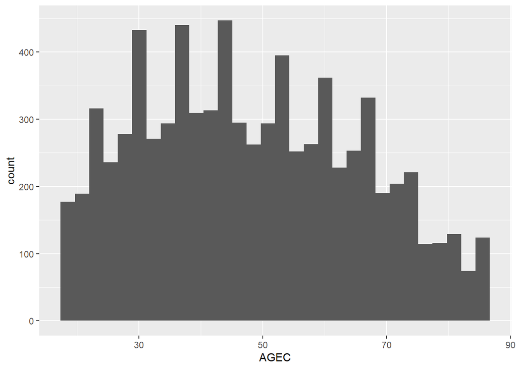

```r
numeric_hist(final, x = "AGEC")
```

These are just graphs of the distribution of each variable

# short analysis

## linear regression with BMI as outcome

```r
bmi_full <- lm(BMISC ~ avg_veges + avg_fruit + avg_dairy + avg_meat + avg_grains + AGEC + SEX, dat = final)
bmi_null <- lm(BMISC ~ 1, dat = final)
```

## linear regression with waist to heigh ratio as outcome

```r
w2hratio_full <- lm(w2hratio ~ avg_veges + avg_fruit + avg_dairy + avg_meat + avg_grains + AGEC + SEX, dat = final)
w2hratio_null <- lm(w2hratio ~ 1, dat = final)
```

## linear regression with waist circumference as outcome

```r
waist_full <- lm(PHDCMWBC ~ avg_veges + avg_fruit + avg_dairy + avg_meat + avg_grains + AGEC + SEX, dat = final)
waist_null <- lm(PHDCMWBC ~ 1, dat = final)
```

NOTE: robust regression was attempted and gave similar results to OLS, so just using OLS instead.

## table of all models

```r
full_model_table <- tab_model(bmi_full, waist_full, w2hratio_full, show.ci = F, show.se = T)
full_model_table
```

|  | BMISC |  |  | PHDCMWBC |  |  | w 2 hratio |  |  |
| --- | --- | --- | --- | --- | --- | --- | --- | --- | --- |
| Predictors | Estimates | std. Error | p | Estimates | std. Error | p | Estimates | std. Error | p |
| (Intercept) | 25.98 | 0.24 | **<0.001** | 89.07 | 0.59 | **<0.001** | 0.49 | 0.00 | **<0.001** |
| avg veges | -0.12 | 0.03 | **<0.001** | -0.29 | 0.08 | **<0.001** | -0.00 | 0.00 | **<0.001** |
| avg fruit | -0.20 | 0.05 | **<0.001** | -0.57 | 0.11 | **<0.001** | -0.00 | 0.00 | **<0.001** |
| avg dairy | 0.10 | 0.07 | 0.141 | 0.18 | 0.16 | 0.255 | -0.00 | 0.00 | 0.275 |
| avg meat | 0.22 | 0.05 | **<0.001** | 0.37 | 0.12 | **0.002** | 0.00 | 0.00 | **0.007** |
| avg grains | -0.17 | 0.03 | **<0.001** | -0.38 | 0.07 | **<0.001** | -0.00 | 0.00 | **<0.001** |
| AGEC | 0.05 | 0.00 | **<0.001** | 0.23 | 0.01 | **<0.001** | 0.00 | 0.00 | **<0.001** |
| SEX [2] | -0.66 | 0.13 | **<0.001** | -10.08 | 0.31 | **<0.001** | -0.02 | 0.00 | **<0.001** |
| Observations | 7811 |  |  | 7811 |  |  | 7811 |  |  |
| R<sup>2</sup> / R<sup>2</sup> adjusted | 0.041 / 0.040 |  |  | 0.190 / 0.190 |  |  | 0.155 / 0.154 |  |  |

dairy is insignificant for all

## Model selection and performance (10 fold CV)

Model selection using backward and forward selection

### BMI

```r
n = nrow(final)

# bmi_AIC is just full model
# bmi_AIC <- step(bmi_full, direction = "backward", trace = F)

bmi_BIC <- step(bmi_full, direction = "backward", trace = F, k = log(n))

# fwd AIC model same as back
# step(bmi_null, scope = list(lower = bmi_null, upper = bmi_full), direction = "forward", trace = F)
```

### waist circumeference

```r
waist_AIC <- step(waist_full, direction = "backward", trace = F)

# waist_BIC same as AIC
# waist_BIC <- step(waist_full, direction = "backward", trace = F, k = log(n))


# backward selection same as fwd
# step(waist_null, scope = list(lower = waist_null, upper = waist_full), direction = "forward", trace = F)
```

### w2h ratio

```r
w2hratio_AIC <- step(w2hratio_full, direction = "backward", trace = F)
w2hratio_BIC <- step(w2hratio_full, direction = "backward", trace = F, k = log(n))

# backward selection same as fwd
# step(w2hratio_null, scope = list(lower = w2hratio_null, upper = waist_full), direction = "forward", trace = F)
```

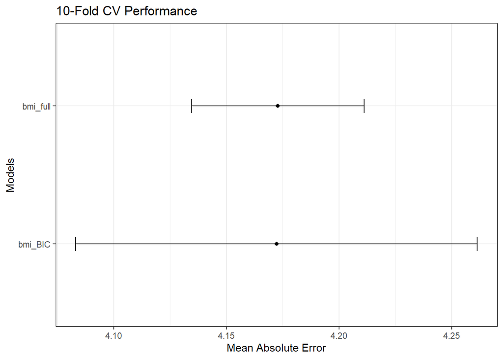

```r
params = trainControl(method = "cv", number = 10, verboseIter = FALSE)

set.seed(2021)

cv_objects = list(
  bmi_full = train(BMISC ~ avg_veges + avg_fruit + avg_dairy + avg_meat +
    avg_grains + AGEC + SEX,
    method = "lm",
    data = final,
    trControl = params),
  bmi_BIC = train(BMISC ~ avg_veges + avg_fruit + avg_meat + avg_grains +
    AGEC + SEX,
    method = "lm",
    data = final,
    trControl = params),
  waist_full = train(PHDCMWBC ~ avg_veges + avg_fruit + avg_dairy + avg_meat + avg_grains + AGEC + SEX,
    method = "lm",
    data = final,
    trControl = params),
  waist_AIC = train(PHDCMWBC ~ avg_veges + avg_fruit + avg_meat + avg_grains + AGEC + SEX,
    method = "lm",
    data = final,
    trControl = params),
  w2hratio_full = train(w2hratio ~ avg_veges + avg_fruit + avg_dairy + avg_meat + avg_grains + AGEC + SEX,
    method = "lm",
    data = final,
    trControl = params),
  w2hratio_AIC = train(w2hratio ~ avg_veges + avg_fruit + avg_meat + avg_grains + AGEC + SEX,
    method = "lm",
    data = final,
    trControl = params),
  w2hratio_BIC = train(w2hratio ~ avg_veges + avg_fruit + avg_grains +
    AGEC + SEX,
    method = "lm",
    data = final,
    trControl = params)
)

cv_results_bmi = resamples(cv_objects[1:2], metric = "Rsquared")
ggplot(cv_results_bmi) +
  theme_bw() +
  labs(x = "Models", y = "Mean Absolute Error", title = "10-Fold CV Performance")
```

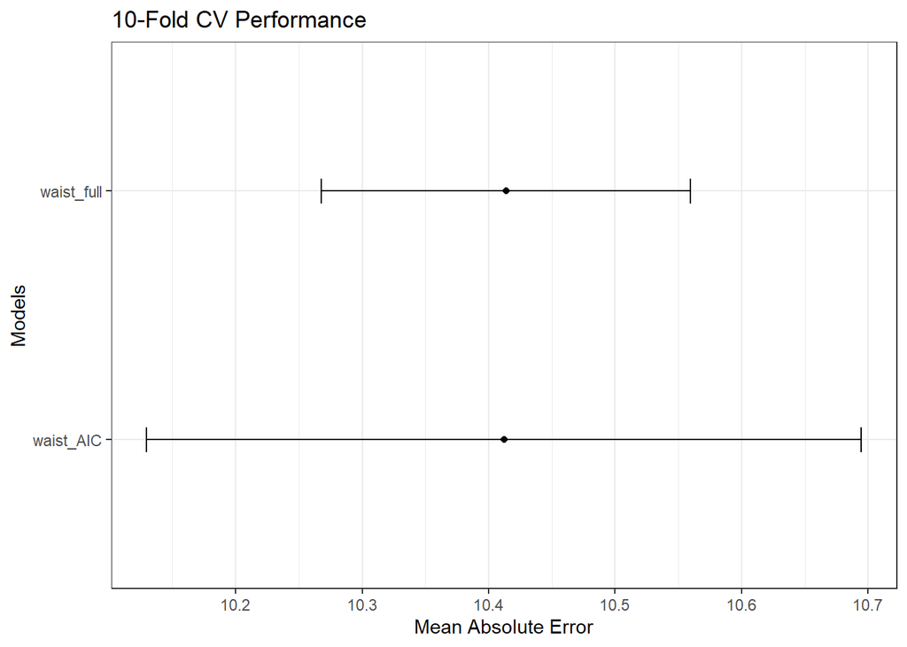

```r
cv_results_waist = resamples(cv_objects[3:4], metric = "Rsquared")
ggplot(cv_results_waist) +
  theme_bw() +
  labs(x = "Models", y = "Mean Absolute Error", title = "10-Fold CV Performance")
```

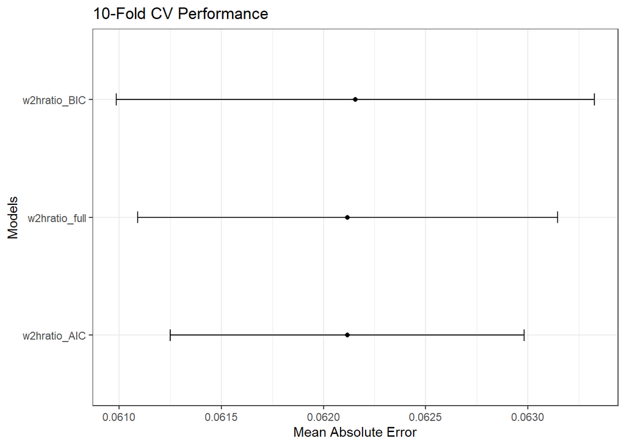

```r
cv_results_w2hratio = resamples(cv_objects[5:7], metric = "Rsquared")
ggplot(cv_results_w2hratio) +
  theme_bw() +
  labs(x = "Models", y = "Mean Absolute Error", title = "10-Fold CV Performance")
```

Don’t worry about these for now

### Regression assumptions

#### First model (full BMI)

```r
model <- cv_objects[1]
model
```

```
## $bmi_full
## Linear Regression
##
## 7811 samples
##    7 predictor
##
## No pre-processing
## Resampling: Cross-Validated (10 fold)
## Summary of sample sizes: 7030, 7030, 7031, 7030, 7029, 7030, ...
## Resampling results:
##
##   RMSE      Rsquared    MAE
##   5.446025  0.04032031  4.172838
##
## Tuning parameter 'intercept' was held constant at a value of TRUE
```

```r
bmi_full <- lm(BMISC ~ avg_veges + avg_fruit + avg_dairy + avg_meat +
  avg_grains + AGEC + SEX,
  method = "lm",
  data = final,
  trControl = params)
summary(bmi_full)
```

```
##
## Call:
## lm(formula = BMISC ~ avg_veges + avg_fruit + avg_dairy + avg_meat +
##     avg_grains + AGEC + SEX, data = final, method = "lm", trControl = params)
##
## Residuals:
##     Min      1Q  Median      3Q     Max
## -13.835  -3.793  -0.854   2.789  35.088
##
## Coefficients:
##              Estimate Std. Error t value Pr(>|t|)
## (Intercept) 25.975387   0.243339 106.746  < 2e-16 ***
## avg_veges   -0.124598   0.032734  -3.806 0.000142 ***
## avg_fruit   -0.198827   0.046527  -4.273 1.95e-05 ***
## avg_dairy    0.097887   0.066491   1.472 0.141009
## avg_meat     0.216046   0.049438   4.370 1.26e-05 ***
## avg_grains  -0.174983   0.028362  -6.170 7.19e-10 ***
## AGEC         0.053893   0.003592  15.005  < 2e-16 ***
## SEX2        -0.663969   0.127662  -5.201 2.03e-07 ***
## ---
## Signif. codes:  0 '***' 0.001 '**' 0.01 '*' 0.05 '.' 0.1 ' ' 1
##
## Residual standard error: 5.445 on 7803 degrees of freedom
## Multiple R-squared:  0.04127,    Adjusted R-squared:  0.04041
## F-statistic: 47.99 on 7 and 7803 DF,  p-value: < 2.2e-16
```

```r
model.diag.metrics <- augment(bmi_full)
head(model.diag.metrics)
```

```
## # A tibble: 6 x 15
##   .rownames BMISC avg_veges avg_fruit avg_dairy avg_meat avg_grains  AGEC SEX
##   <chr>     <dbl>     <dbl>     <dbl>     <dbl>    <dbl>      <dbl> <int> <fct>
## 1 1          20.9     3.62      0.412      2.51     4.96       6.11    46 2
## 2 2          29.8     2.95      2.03       1.44     2.19       3.45    77 1
## 3 3          24.4     9.08      1.34       1.87     3.04       2.45    55 2
## 4 4          21.4     5.87      5.06       3.64     2.79       2.35    59 2
## 5 6          25.1     4.54      0.154      1.59     1.56       1.67    35 2
## 6 8          30.7     0.706     0          1.77     1.59       3.56    35 1
## # ... with 6 more variables: .fitted <dbl>, .resid <dbl>, .hat <dbl>,
## #   .sigma <dbl>, .cooksd <dbl>, .std.resid <dbl>
```

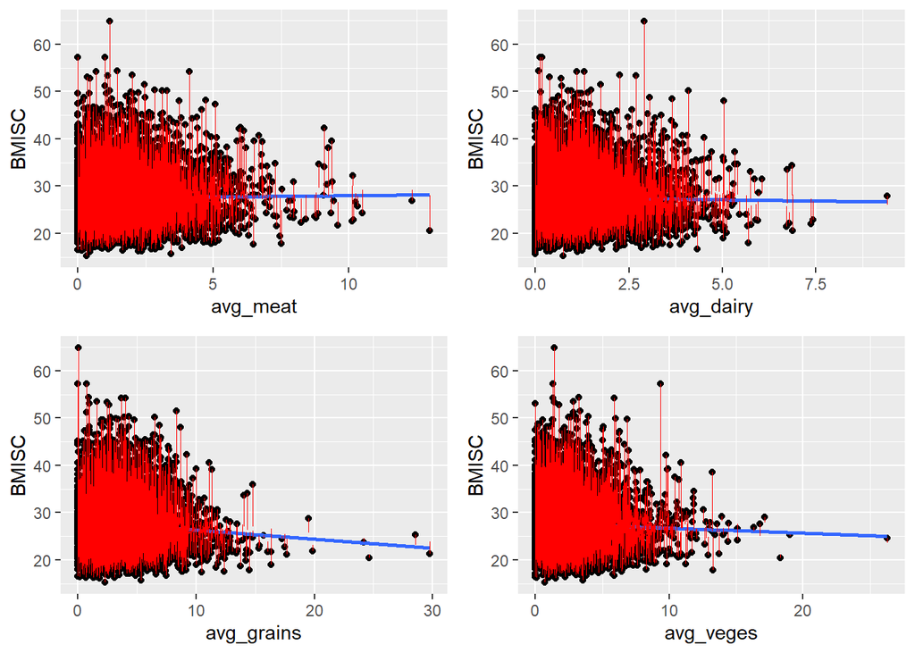

```r
plot1 <- ggplot(model.diag.metrics, aes(avg_meat, BMISC)) +
  geom_point() +
  stat_smooth(method = lm, se = FALSE) +
  geom_segment(aes(xend = avg_meat, yend = .fitted), color = "red", size = 0.3)
plot2 <- ggplot(model.diag.metrics, aes(avg_dairy, BMISC)) +
  geom_point() +
  stat_smooth(method = lm, se = FALSE) +
  geom_segment(aes(xend = avg_dairy, yend = .fitted), color = "red", size = 0.3)
plot3 <- ggplot(model.diag.metrics, aes(avg_grains, BMISC)) +
  geom_point() +
  stat_smooth(method = lm, se = FALSE) +
  geom_segment(aes(xend = avg_grains, yend = .fitted), color = "red", size = 0.3)
plot4 <- ggplot(model.diag.metrics, aes(avg_veges, BMISC)) +
  geom_point() +
  stat_smooth(method = lm, se = FALSE) +
  geom_segment(aes(xend = avg_veges, yend = .fitted), color = "red", size = 0.3)


grid.arrange(plot1, plot2, plot3, plot4, ncol=2)
```

The residuals mostly seem to follow the same pattern across features

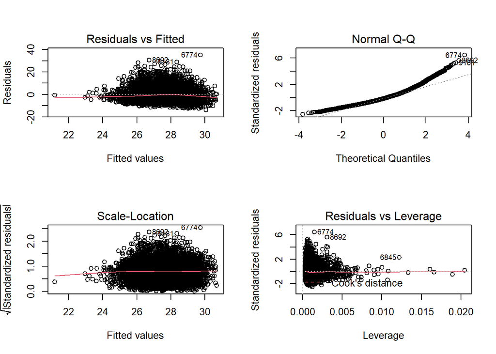

```r
par(mfrow=c(2,2))
plot(bmi_full)
```

## comaring standardized betas

```r
# creating scaled df
sex <- final$SEX
socioeconomic <- final$SF2SA1QN
scaled_df <- final %>%
  dplyr::select(-c(SEX, SF2SA1QN)) %>%
  scale() %>% as.data.frame()


scaled_df$SEX <- sex
scaled_df$SF2SA1QN <- socioeconomic

# lm scaled to get standardized betas to compare
bmi_scaled <- lm(BMISC ~ avg_veges + avg_fruit + avg_dairy + avg_meat + avg_grains + AGEC + SEX, dat = scaled_df)
w2h_scaled <- lm(w2hratio ~ avg_veges + avg_fruit + avg_dairy + avg_meat + avg_grains + AGEC + SEX, dat = scaled_df)
waist_scaled <- lm(PHDCMWBC ~ avg_veges + avg_fruit + avg_dairy + avg_meat + avg_grains + AGEC + SEX, dat = scaled_df)
```

```r
st_beta_table <- tab_model(bmi_scaled, w2h_scaled, waist_scaled)
st_beta_table
```

|  | BMISC |  |  | w 2 hratio |  |  | PHDCMWBC |  |  |
| --- | --- | --- | --- | --- | --- | --- | --- | --- | --- |
| Predictors | Estimates | CI | p | Estimates | CI | p | Estimates | CI | p |
| (Intercept) | 0.06 | 0.03 – 0.09 | **<0.001** | 0.09 | 0.06 – 0.12 | **<0.001** | 0.36 | 0.33 – 0.39 | **<0.001** |
| avg veges | -0.05 | -0.07 – -0.02 | **<0.001** | -0.05 | -0.07 – -0.03 | **<0.001** | -0.04 | -0.06 – -0.02 | **<0.001** |
| avg fruit | -0.05 | -0.07 – -0.03 | **<0.001** | -0.07 | -0.09 – -0.05 | **<0.001** | -0.05 | -0.07 – -0.03 | **<0.001** |
| avg dairy | 0.02 | -0.01 – 0.04 | 0.141 | -0.01 | -0.03 – 0.01 | 0.275 | 0.01 | -0.01 – 0.03 | 0.255 |
| avg meat | 0.05 | 0.03 – 0.08 | **<0.001** | 0.03 | 0.01 – 0.05 | **0.007** | 0.03 | 0.01 – 0.06 | **0.002** |
| avg grains | -0.08 | -0.10 – -0.05 | **<0.001** | -0.05 | -0.08 – -0.03 | **<0.001** | -0.06 | -0.09 – -0.04 | **<0.001** |
| AGEC | 0.17 | 0.15 – 0.19 | **<0.001** | 0.38 | 0.36 – 0.40 | **<0.001** | 0.28 | 0.26 – 0.30 | **<0.001** |
| SEX [2] | -0.12 | -0.16 – -0.07 | **<0.001** | -0.18 | -0.22 – -0.14 | **<0.001** | -0.69 | -0.73 – -0.64 | **<0.001** |
| Observations | 7811 |  |  | 7811 |  |  | 7811 |  |  |
| R<sup>2</sup> / R<sup>2</sup> adjusted | 0.041 / 0.040 |  |  | 0.155 / 0.154 |  |  | 0.190 / 0.190 |  |  |

# pca and clustering to see any trends in obesity

```r
food_groups <- final %>% dplyr::select(avg_dairy,
                                avg_fruit,
                                avg_grains,
                                avg_meat,
                                avg_veges)

numerics <- final %>% dplyr::select(-SEX,
                                    -SF2SA1QN)

# principal component analysis
res.pca <- prcomp(
  food_groups,
  center = T,
  scale = T
)

# extracting pc1 and pc2
pcs = res.pca$x[, c(1,2)] %>% as.data.frame()
```

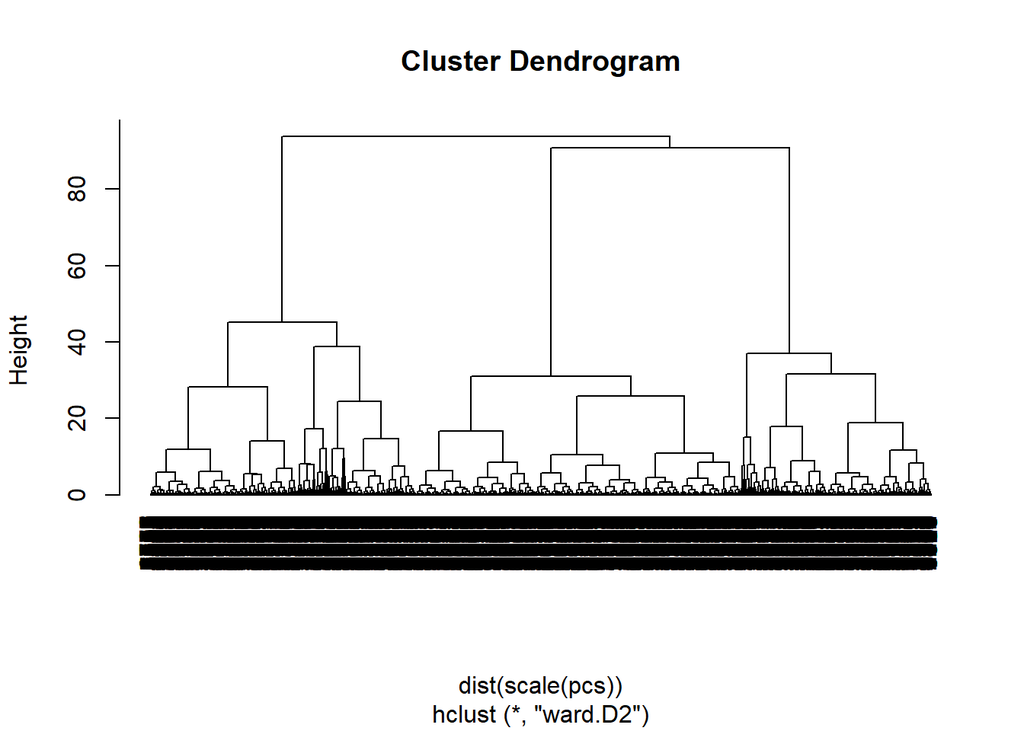

```r
## keeping original data
pcs1 <- pcs
## Creating k-means clustering model
fit_cluster_kmeans_pca <- kmeans(scale(pcs), 5)
# Assigning the result to the data used to create the tsne
pcs1$cl_kmeans <- factor(fit_cluster_kmeans_pca$cluster)
# Creating hierarchical cluster model
fit_cluster_hierarchical_pca <- hclust(dist(scale(pcs)), method = "ward.D2")

plot(fit_cluster_hierarchical_pca, hang = -1)
```

```r
#  Assigning the result to the data used
pcs1$cl_hierarchical <- factor(cutree(fit_cluster_hierarchical_pca, k=5))


pcs1$BMISC <- final$BMISC
pcs1$obese <- pcs1$BMISC >= 30


cluster_ggplot <- pcs1 %>%
  ggplot(aes(x = PC1,
             y = PC2))+
  geom_point(aes(color=obese),
             alpha = 0.5)+
  scale_color_manual(values = c("#964B00", "#8F00FF",  "#0000FF", "#00FF00",
                                "#FFA500", "#808080", "#FF0000")) +
    geom_mark_ellipse(aes(color = cl_hierarchical,
                        label=cl_hierarchical),
                    expand = unit(0.5,"mm"),
                    label.buffer = unit(-5, 'mm')) +
  theme(legend.position = "none")



prop_obese <- pcs1 %>% group_by(cl_hierarchical) %>%
  summarise(prop_obese = sum(as.numeric(obese))/n()) %>% kbl()
```

```r
scaled_numerics <- scale(numerics)
scaled_numerics <- as.data.frame(scaled_numerics)
scaled_numerics$cl_hierarchical <- pcs1$cl_hierarchical


clusters_characteristics <- scaled_numerics %>% group_by(cl_hierarchical) %>%
  summarise(avg_veges = mean(avg_veges) %>% round(2),
            avg_dairy = mean(avg_dairy) %>% round(2),
            avg_fruit = mean(avg_fruit) %>% round(2),
            avg_meat = mean(avg_meat) %>% round(2),
            avg_grains = mean(avg_grains) %>% round(2),
            avg_age = mean(AGEC) %>% round(2),
            avg_bmi = mean(BMISC) %>% round(2),
            avg_waist = mean(PHDCMWBC) %>% round(2),
            avg_w2hratio = mean(w2hratio) %>% round(2))
```

Table above shows how many standard deviations away from 0 each cluster is in each variable.